# R exam

# Exam R

Mark Klik & Misja Mikkers

# Introduction

Before you turn this problem in, make sure everything runs as expected. First, **restart the kernel** (in the menubar, select Kernel$\rightarrow$Restart) and then **run all cells** (in the menubar, select Cell$\rightarrow$Run All).

Make sure you fill in any place that says `YOUR CODE HERE` or “YOUR ANSWER HERE”, as well as your name and collaborators below:

```r
NAME = "Rik Gommans, 2015054"
COLLABORATORS = ""
```

Fill in the cell above to provide us with your name and student number, like

NAME = “Adam Smith, #student number#”

where you replace “#student number#” with your … (very good!)

Unfortunately, you are not allowed to work with “COLLABORATORS” in this exam.

## exam September 21th, 2018

With this R part of the exam you can earn at max. 4 points.

In the first cell of the notebook, give us your name and student number in the way indicated above.

Fill in the notebook (see below for code cells and text cells that you need to fill in).

If you look at the menus above (File, Edit, View etc.), there is one called “Cell”. If you click on this, you can change the “Cell Type”. Choose “Code” when you are typing python or R code. Choose “Markdown” when you are typing, well, markdown.

When you finish the notebook, make sure that you save it with the output of your code included.

# Packages

You will need the following packages for this exam.

```r
library(tidyverse)
```

# Assignment 1

## Data

Please read in “Medicaid.csv” and check the structure.

If needed change the variables Recipients and Total_costs into a numeric variable.

Hint: don’t forget you cannot change a factor in a numeric variable directly!

```r
medicaid <- read.csv2('../data/Medicaid.csv', dec=',')
show(medicaid)
```

| Year | Recipients | Total_costs |
| --- | --- | --- |
| 2003 | 4267573 | 36142075737 |
| 2004 | 4594667 | 38926018824 |
| 2005 | 4733617 | 40803778540 |
| 2006 | 4730167 | 40712547369 |
| 2007 | 4622782 | 42127412366 |
| 2008 | 4657242 | 44239141758 |
| 2009 | 4911408 | 47021820192 |
| 2010 | 5212444 | 49221108692 |
| 2011 | 5398722 | 49975969554 |
| 2012 | 5598237 | 49734737508 |

[output cut: 3 more lines]

```r
medicaid <- read.csv2('../data/Medicaid.csv', dec=',') %>%
  mutate(Recipients= as.numeric(as.character(Recipients))) %>%
  mutate(Total_costs= as.numeric(as.character(Total_costs)))

str(medicaid)
```

```
'data.frame':   13 obs. of  3 variables:
 $ Year       : int  2003 2004 2005 2006 2007 2008 2009 2010 2011 2012 ...
 $ Recipients : num  4267573 4594667 4733617 4730167 4622782 ...
 $ Total_costs: num  3.61e+10 3.89e+10 4.08e+10 4.07e+10 4.21e+10 ...
```

## New variable

You will now have to make a new variable called “Cost_per_Recipient” by dividing the variable “Total_Costs” by the variable “Recipients”. You will have to use the “pipe-operator”. You have to show the “head” of the dataframe.

```r
medicaid$Cost_per_Recipient <- medicaid$Total_costs/medicaid$Recipients
head(medicaid)
```

|  | Year | Recipients | Total_costs | Cost_per_Recipient |
| --- | --- | --- | --- | --- |
| 1 | 2003 | 4267573 | 36142075737 | 8469 |
| 2 | 2004 | 4594667 | 38926018824 | 8472 |
| 3 | 2005 | 4733617 | 40803778540 | 8620 |
| 4 | 2006 | 4730167 | 40712547369 | 8607 |
| 5 | 2007 | 4622782 | 42127412366 | 9113 |
| 6 | 2008 | 4657242 | 44239141758 | 9499 |

## Plot 1

Now you have to make a line plot of the data:

- with Year on the x-axis
- Cost_per_Recipient on the y-axis
- The line should have size 3 and the color “red”
- The name on the Y axis should be “Cost per enrollee”

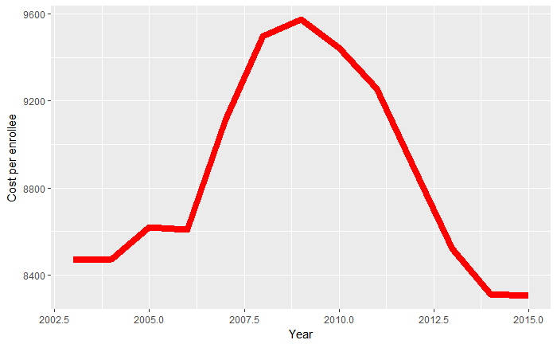

```r
ggplot(medicaid, aes(x=Year, y=Cost_per_Recipient,group=1)) +
  geom_line(color="red", size=3) +
  labs(x="Year", y="Cost per enrollee")
```

End of notebook